# Tarea 6. Ecuaciones diferenciales ordinarias.

Autor/a

Alexander Fuentes Gómez

Packages requeridos:

**Código**

```python
import numpy as np
import matplotlib.pyplot as plt
import plotly.graph_objects as go
from scipy import integrate
```

**Código**

```python
PALETA = ['tab:blue', 'tab:red', 'tab:green', 'tab:purple']

def resolver_y_graficar(f, t0, tf, s0, etiquetas, titulo='',
                        n_pts=1000, args=None, ylabel=None, metodo='RK45'):
    """
    Resuelve un sistema de EDOs de primer orden con solve_ivp y grafica las
    componentes en una sola figura, todas vs t.
    """
    t_vals = np.linspace(t0, tf, n_pts)
    kw = dict(t_eval=t_vals, method=metodo, rtol=1e-8, atol=1e-10)
    if args is not None:
        kw['args'] = args
    sol = integrate.solve_ivp(f, [t0, tf], s0, **kw)

    plt.figure(figsize=(9, 5))
    for i, lab in enumerate(etiquetas):
        plt.plot(sol.t, sol.y[i], color=PALETA[i % len(PALETA)], lw=2, label=lab)
    plt.xlabel('t')
    plt.ylabel(ylabel if ylabel else '/'.join(etiquetas))
    if titulo:
        plt.title(titulo)
    plt.legend()
    plt.grid(True, alpha=0.4)
    plt.show()
    return sol


def resolver_funciones_y_trayectoria(f, t0, tf, s0, etiquetas, titulo='',
                                     n_pts=2000, args=None, metodo='RK45'):
    """
    Igual que la anterior pero, además de la gráfica de las componentes vs t,
    dibuja la trayectoria (componente 0 vs componente 1) en un segundo eje.
    """
    t_vals = np.linspace(t0, tf, n_pts)
    kw = dict(t_eval=t_vals, method=metodo, rtol=1e-8, atol=1e-10)
    if args is not None:
        kw['args'] = args
    sol = integrate.solve_ivp(f, [t0, tf], s0, **kw)

    fig, axes = plt.subplots(1, 2, figsize=(15, 5))
    for i, lab in enumerate(etiquetas):
        axes[0].plot(sol.t, sol.y[i], color=PALETA[i % len(PALETA)], lw=2, label=lab)
    axes[0].set_xlabel('t'); axes[0].set_ylabel('/'.join(etiquetas))
    axes[0].legend(); axes[0].grid(True, alpha=0.4)
    axes[0].set_title(f'Funciones {titulo}')

    axes[1].plot(sol.y[0], sol.y[1], color='navy', lw=1.5)
    axes[1].plot(s0[0], s0[1], 'o', color='firebrick', ms=8, label='Inicio')
    axes[1].set_xlabel(etiquetas[0]); axes[1].set_ylabel(etiquetas[1])
    axes[1].legend(); axes[1].grid(True, alpha=0.4)
    axes[1].set_title(f'Trayectoria {titulo}')

    plt.tight_layout()
    plt.show()
    return sol
```

# Ejercicio 1

La Ley de Enfriamiento de Newton establece que la tasa de enfriamiento de un objeto es proporcional a la diferencia de temperatura entre el objeto y su entorno. Supongamos que $t$ es el tiempo, $T$ es la temperatura del objeto, y $T_s$ es la temperatura del entorno. La siguiente ecuación diferencial describe la Ley de Newton:
$$\begin{equation}
\frac{dT}{dt} = k(T - T_s),
\end{equation}$$

donde $k$ es una constante.

Consideramos una taza de café a 95 °C en una habitación de 18 °C. Se sabe que el café se enfría a una razón de 2 °C/min cuando su temperatura es de 70 °C. Calcula el valor de la constante $k$ y brinda una gráfica de la solución de la ecuación diferencial.

**Cálculo de la constante.** Cuando $T=70\,°\!C$ se tiene $\dfrac{dT}{dt}=-2\,°\!C/\text{min}$ (se enfría, de ahí el signo negativo). Sustituyendo en la ecuación:
$$-2 = k\,(70 - 18) = 52k \;\Rightarrow\; k = -\dfrac{2}{52} = -\dfrac{1}{26}\approx -0.03846.$$

**Solución analítica:** $T(t) = T_s + (T_0 - T_s)\,e^{kt} = 18 + 77\,e^{-t/26}$.

**Código**

```
k = -0.038462  (= -1/26)
```

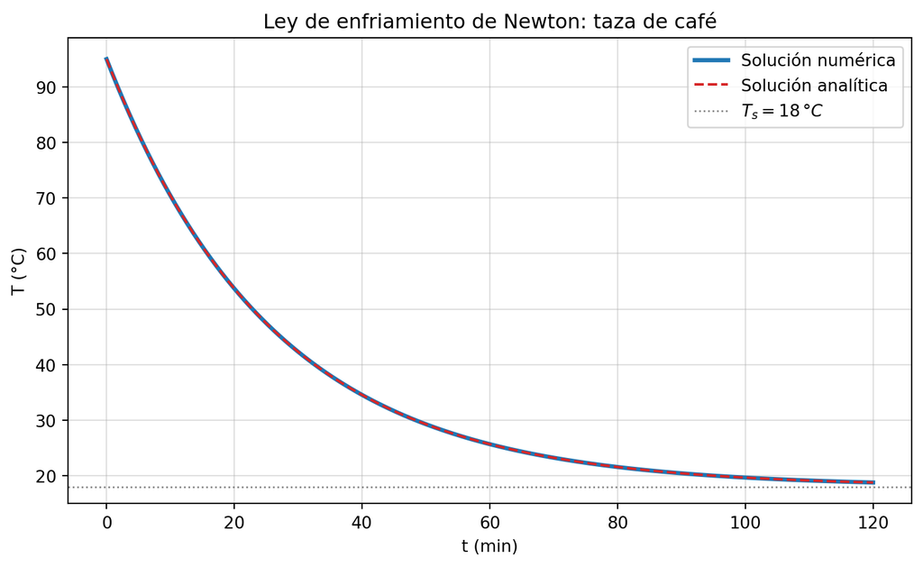

```python
T_s = 18
T_0 = 95
k = -2/52
print(f"k = {k:.6f}  (= -1/26)")

# Sistema (de primer orden, una sola ecuación)
def f_newton(t, T, k, Ts):
    return [k*(T[0] - Ts)]

t0, tf = 0, 120  # 2 horas
sol = integrate.solve_ivp(f_newton, [t0, tf], [T_0], args=(k, T_s),
                          t_eval=np.linspace(t0, tf, 400), rtol=1e-8, atol=1e-10)

# Solución analítica para comparar
t = sol.t
T_exacta = T_s + (T_0 - T_s)*np.exp(k*t)

plt.figure(figsize=(9, 5))
plt.plot(t, sol.y[0], color='tab:blue', lw=2.5, label='Solución numérica')
plt.plot(t, T_exacta, '--', color='tab:red', lw=1.5, label='Solución analítica')
plt.axhline(T_s, color='gray', ls=':', lw=1, label=f'$T_s = {T_s}\\,°C$')
plt.xlabel('t (min)'); plt.ylabel('T (°C)')
plt.title('Ley de enfriamiento de Newton: taza de café')
plt.legend(); plt.grid(True, alpha=0.4)
plt.show()
```

La temperatura del café decae exponencialmente desde 95 °C hacia la temperatura ambiente de 18 °C. El tiempo característico es $\tau = 1/|k| = 26$ minutos.

# Ejercicio 2

Brinda una aproximación de la solución del siguiente problema con valor inicial.
$$\begin{equation}
y' = t -ty, \qquad y(1)=0.
\end{equation}$$

Como $y'=t(1-y)$ es separable, $\frac{dy}{1-y}=t\,dt$, integrando y aplicando la condición inicial obtenemos la **solución analítica**
$$y(t)=1-e^{-(t^{2}-1)/2}.$$

**Código**

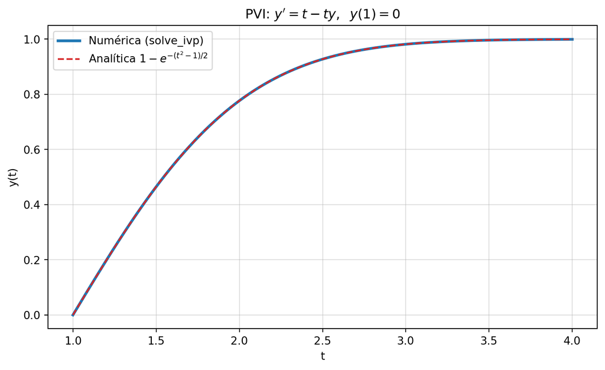

```
Error máximo entre numérica y analítica: 3.95e-10
```

```python
def f_pvi(t, y):
    return [t - t*y[0]]

t0, tf = 1, 4
sol = integrate.solve_ivp(f_pvi, [t0, tf], [0], t_eval=np.linspace(t0, tf, 300),
                          rtol=1e-9, atol=1e-11)
t = sol.t
y_exact = 1 - np.exp(-(t**2 - 1)/2)

plt.figure(figsize=(9, 5))
plt.plot(t, sol.y[0], color='tab:blue', lw=2.5, label='Numérica (solve_ivp)')
plt.plot(t, y_exact, '--', color='tab:red', lw=1.5, label=r'Analítica $1-e^{-(t^2-1)/2}$')
plt.xlabel('t'); plt.ylabel('y(t)')
plt.title(r"PVI: $y' = t - ty,\;\; y(1)=0$")
plt.legend(); plt.grid(True, alpha=0.4)
plt.show()

print(f"Error máximo entre numérica y analítica: {np.max(np.abs(sol.y[0] - y_exact)):.2e}")
```

# Ejercicio 3

Para la siguiente ecuación diferencial ordinaria de segundo orden con valores iniciales
$$\begin{equation}
u''-3u'-1.5 u= 8\,sen(3t), \qquad u(1)=-0.5, u'(1)=1
\end{equation}$$

Escribe el respectivo sistema de ecuaciones diferenciales de primer orden considerando que $v=u'(t)$ (velocidad) y posteriormente brinda la solución del sistema por medio de las funciones $u(t)$ y $v(t)$

Esta ecuación diferencial ordinaria de segundo orden se puede reescribir como el siguiente sistema de primer orden:
$$\begin{eqnarray}
u' & = & v \\
v' &=& 3v + 1.5u + 8\sin(3t)
\end{eqnarray}$$

con los valores iniciales $u(1)=-0.5$ y $v(1)=1$.

A continuación se muestra la aproximación de la solución del sistema de ecuaciones diferenciales ordinarias de primer orden y las gráficas de las funciones $u(t)$ y $v(t)$. Notar que $v(t)$ es la derivada de $u(t)$ y esta última es la función que resuelve la ecuación diferencial ordinaria de segundo orden dada en el enunciado.

**Código**

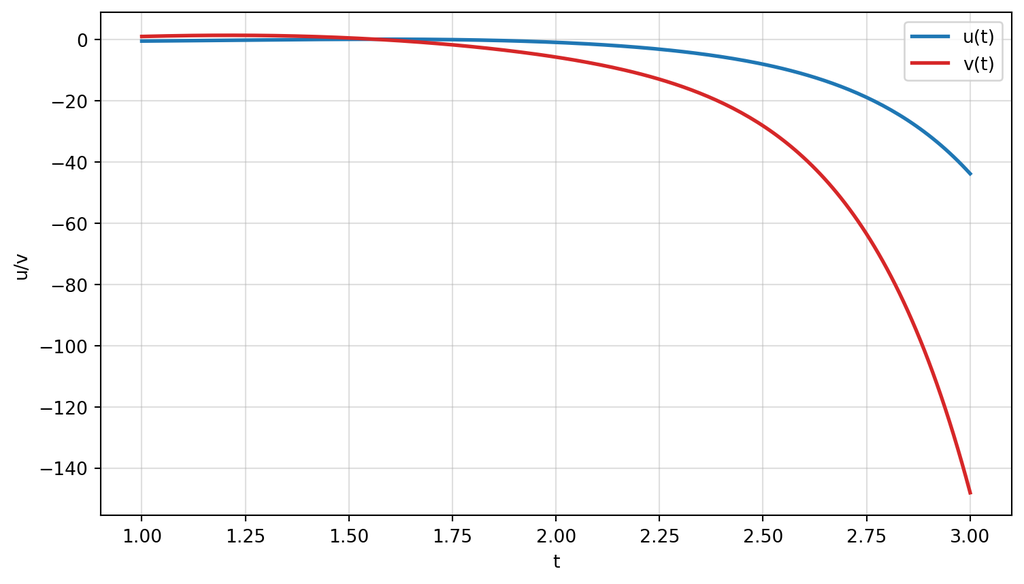

```python
# Función que define el sistema de ecuaciones diferenciales ordinarias de primer orden
def f(t, U):
  u, v = U
  return[v, 8*np.sin(3*t)+3*v+1.5*u]

# Intervalo de tiempo y condiciones iniciales
t0 = 1
tf = 3
s0 = [-0.5, 1]
t_values = np.linspace(t0, tf, 200)

# Aproximación de la solución del sistema de ecuaciones diferenciales ordinarias de primer orden
edo_sol = integrate.solve_ivp(f, [t0, tf], s0, t_eval = t_values)

# Gráfica de las funciones u(t) y v(t)
plt.figure(figsize=(9, 5))
plt.plot(edo_sol.t, edo_sol.y[0], color='tab:blue', lw=2, label = 'u(t)')
plt.plot(edo_sol.t, edo_sol.y[1], color='tab:red',  lw=2, label = 'v(t)')
plt.xlabel('t')
plt.ylabel('u/v')
plt.legend()
plt.grid(True, alpha=0.4)
plt.show()
```

Para cada una de las ecuaciones diferenciales ordinarias de segundo y tercer orden con valores iniciales de los ejercicios 4 al 18, encuentra el respectivo sistema de primer orden y aproxima la solución, brinda gráficas de cada una de las funciones que resulten del sistema.

# Ejercicio 4

**Oscilador armónico simple**

$$\begin{equation}
y'' + 4y = 0,\quad y(0) = 1,\ y'(0) = 0
\end{equation}$$

Con $v=y'$ se obtiene el sistema
$$y'=v,\qquad v'=-4y.$$

**Código**

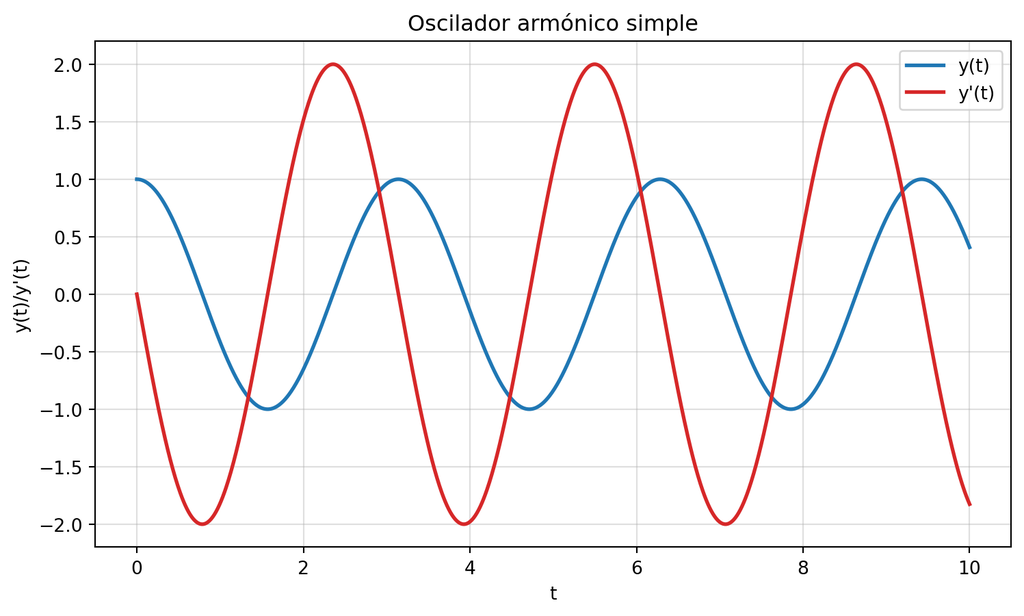

```python
def f4(t, U):
    y, v = U
    return [v, -4*y]

resolver_y_graficar(f4, 0, 10, [1, 0], ['y(t)', "y'(t)"],
                    titulo='Oscilador armónico simple');
```

La solución analítica es $y(t)=\cos(2t)$: oscilación pura, amplitud constante.

# Ejercicio 5

**Oscilador amortiguado**

$$\begin{equation}
y'' + 0.5y' + 4y = 0,\quad y(0) = 2,\ y'(0) = 0
\end{equation}$$

Con $v=y'$:
$$y'=v,\qquad v'=-0.5\,v-4y.$$

**Código**

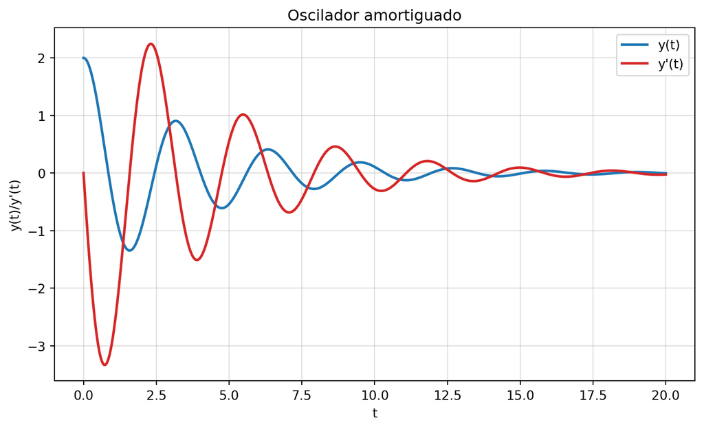

```python
def f5(t, U):
    y, v = U
    return [v, -0.5*v - 4*y]

resolver_y_graficar(f5, 0, 20, [2, 0], ['y(t)', "y'(t)"],
                    titulo='Oscilador amortiguado');
```

La amplitud decae exponencialmente debido al término disipativo $0.5\,y'$.

# Ejercicio 6

**Oscilador forzado**

$$\begin{equation}
y'' + 2y' + y = \cos(t),\quad y(0) = 0,\ y'(0) = 1
\end{equation}$$

$$y'=v,\qquad v'=\cos(t)-2v-y.$$

**Código**

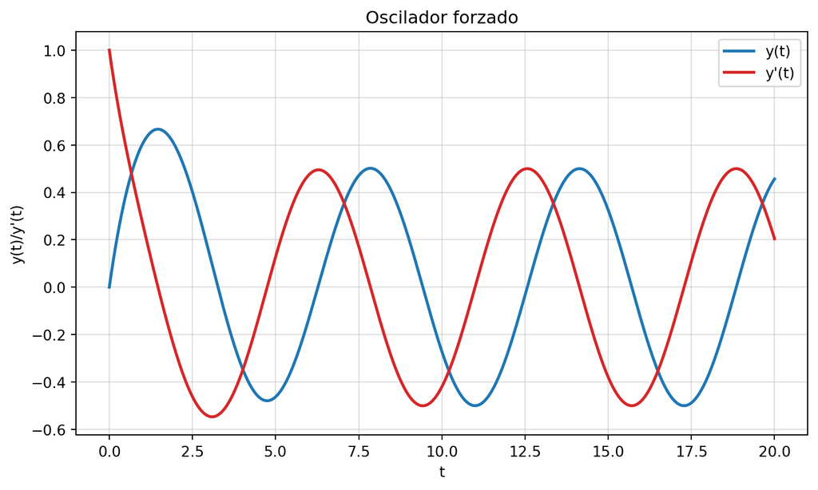

```python
def f6(t, U):
    y, v = U
    return [v, np.cos(t) - 2*v - y]

resolver_y_graficar(f6, 0, 20, [0, 1], ['y(t)', "y'(t)"],
                    titulo='Oscilador forzado');
```

El sistema es críticamente amortiguado ($\zeta=1$); el transitorio se extingue rápidamente y la solución tiende a una oscilación estacionaria con la frecuencia del forzante.

# Ejercicio 7

**Ecuación no lineal de segundo orden**

$$\begin{equation}
y'' = -y^3 + \cos(t),\quad y(0) = 0,\ y'(0) = 0
\end{equation}$$

$$y'=v,\qquad v'=-y^{3}+\cos(t).$$

**Código**

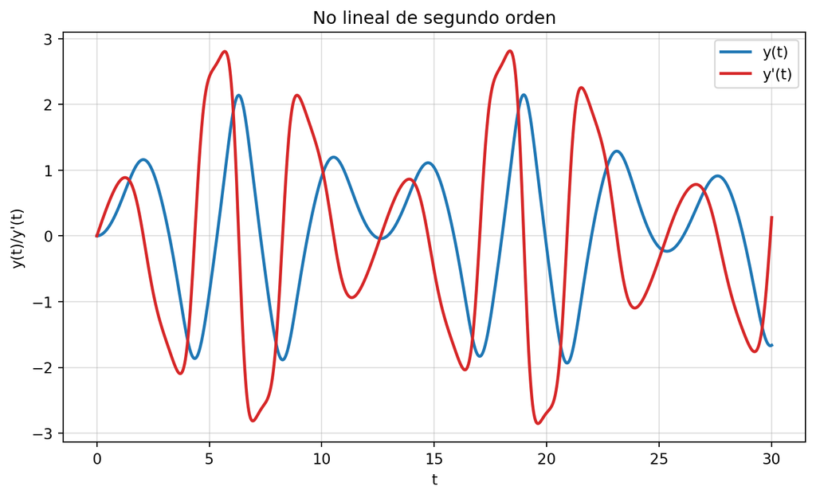

```python
def f7(t, U):
    y, v = U
    return [v, -y**3 + np.cos(t)]

resolver_y_graficar(f7, 0, 30, [0, 0], ['y(t)', "y'(t)"],
                    titulo='No lineal de segundo orden');
```

# Ejercicio 8

**Amortiguamiento cuadrático**

$$\begin{equation}
y'' + y'^2 + y = 0,\quad y(0) = 1,\ y'(0) = -1
\end{equation}$$

$$y'=v,\qquad v'=-v^{2}-y.$$

**Código**

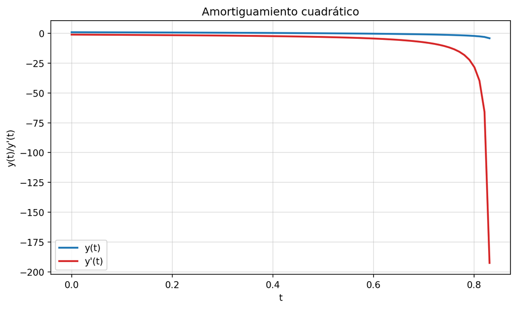

```python
def f8(t, U):
    y, v = U
    return [v, -v**2 - y]

resolver_y_graficar(f8, 0, 10, [1, -1], ['y(t)', "y'(t)"],
                    titulo='Amortiguamiento cuadrático');
```

# Ejercicio 9

**Péndulo simple (no lineal)**

$$\begin{equation}
\theta'' + \sin(\theta) = 0,\quad \theta(0) = \frac{\pi}{4},\ \theta'(0) = 0
\end{equation}$$

Con $\omega=\theta'$:
$$\theta'=\omega,\qquad \omega'=-\sin(\theta).$$

**Código**

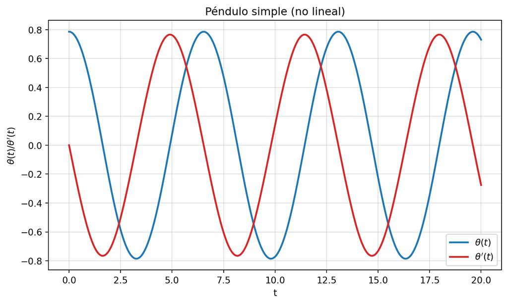

```python
def f9(t, U):
    th, w = U
    return [w, -np.sin(th)]

resolver_y_graficar(f9, 0, 20, [np.pi/4, 0], [r'$\theta(t)$', r"$\theta'(t)$"],
                    titulo='Péndulo simple (no lineal)');
```

Sin disipación, el péndulo oscila indefinidamente; el periodo es ligeramente mayor que $2\pi$ (el del oscilador linealizado) debido a la no linealidad de $\sin(\theta)$.

# Ejercicio 10

**Circuito RLC**

$$\begin{equation}
LQ'' + RQ' + \frac{1}{C}Q = V(t),\quad Q(0) = 0,\ Q'(0) = 0,\quad V(t) = \sin(t)
\end{equation}$$

Considera $L = 0.5$, $R = 2$ y $C = 5$ para este ejercicio.

**Código**

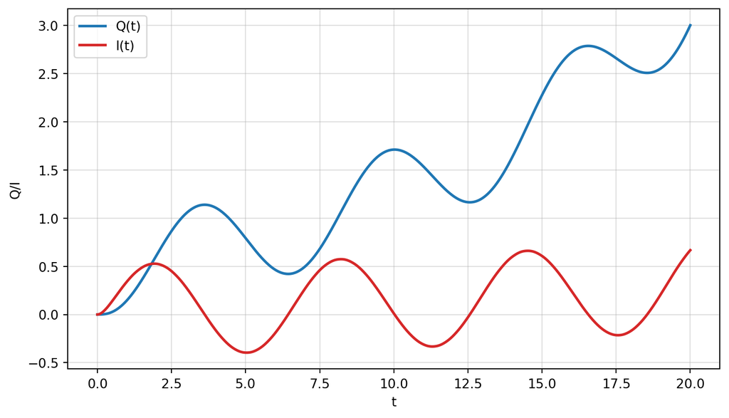

```python
def f(t, Q, L, R, C):
  q, i = Q
  return[i, (1/L)*(np.sin(t)-R*i+q/C)]

L =0.5
R = 2
C= 5

t0 = 0
tf = 20
s0 = [0, 0]
t_values = np.linspace(t0, tf, 1000)

edo_sol = integrate.solve_ivp(f, [t0, tf], s0, t_eval = t_values, args = (L, R, C))

plt.figure(figsize=(9, 5))
plt.plot(edo_sol.t, edo_sol.y[0], color='tab:blue', lw=2, label = 'Q(t)')
plt.plot(edo_sol.t, edo_sol.y[1], color='tab:red',  lw=2, label = 'I(t)')
plt.xlabel('t')
plt.ylabel('Q/I')
plt.legend()
plt.grid(True, alpha=0.4)
plt.show()
```

# Ejercicio 11

**Ecuación de Bessel aproximada**

$$\begin{equation}
x^2y'' + xy' + (x^2 - 1)y = 0,\quad y(1) = 0.5,\ y'(1) = -0.1
\end{equation}$$

Despejando $y''$: $y''=-\dfrac{y'}{x}-\left(1-\dfrac{1}{x^{2}}\right)y$. Con $v=y'$:
$$y'=v,\qquad v'=-\frac{v}{x}-\Bigl(1-\frac{1}{x^{2}}\Bigr)y.$$

**Código**

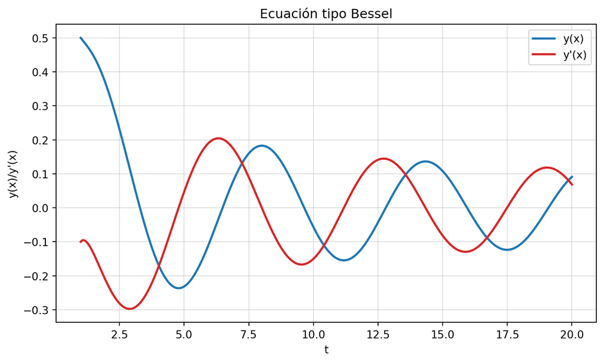

```python
def f11(x, U):
    y, v = U
    return [v, -v/x - (1 - 1/x**2)*y]

resolver_y_graficar(f11, 1, 20, [0.5, -0.1], ['y(x)', "y'(x)"],
                    titulo='Ecuación tipo Bessel');
```

La solución es una combinación lineal de las funciones de Bessel de primera y segunda clase de orden 1 y oscila con amplitud lentamente decreciente como $1/\sqrt{x}$.

# Ejercicio 12

**No lineal con exponencial**

$$\begin{equation}
y'' + y e^y = \sin(t),\quad y(0) = 0,\ y'(0) = 1
\end{equation}$$

$$y'=v,\qquad v'=\sin(t)-y\,e^{y}.$$

**Código**

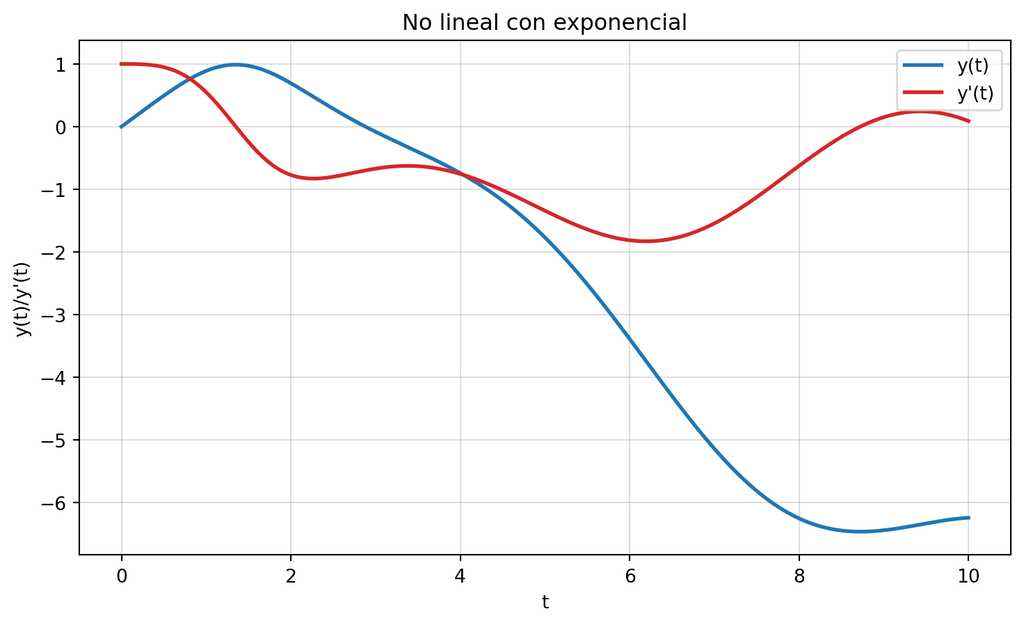

```python
def f12(t, U):
    y, v = U
    return [v, np.sin(t) - y*np.exp(y)]

resolver_y_graficar(f12, 0, 10, [0, 1], ['y(t)', "y'(t)"],
                    titulo='No lineal con exponencial');
```

# Ejercicio 13

**Cuerda con fuerza externa**

$$\begin{equation}
y'' = -\pi^2 y + \cos(2\pi t),\quad y(0) = 1,\ y'(0) = 0
\end{equation}$$

$$y'=v,\qquad v'=-\pi^{2}y+\cos(2\pi t).$$

**Código**

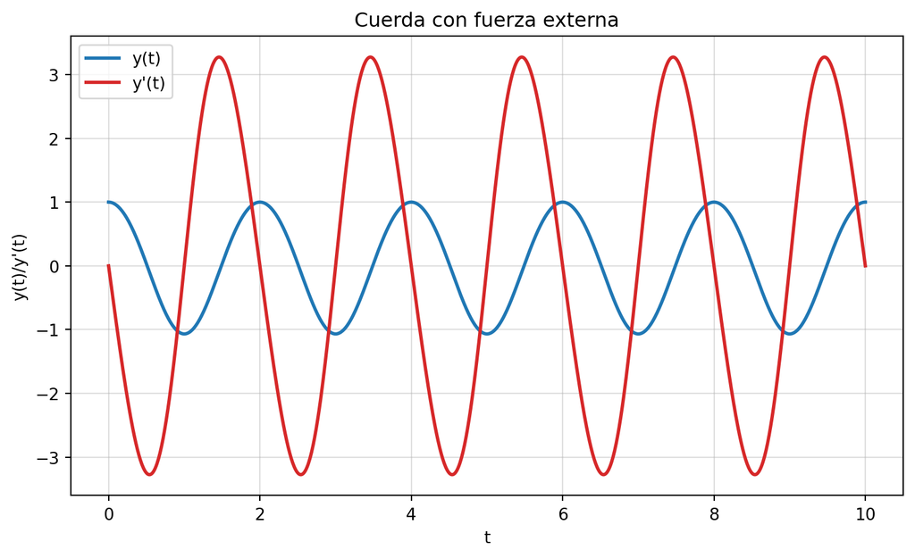

```python
def f13(t, U):
    y, v = U
    return [v, -np.pi**2*y + np.cos(2*np.pi*t)]

resolver_y_graficar(f13, 0, 10, [1, 0], ['y(t)', "y'(t)"],
                    titulo='Cuerda con fuerza externa');
```

La frecuencia natural ($\pi$) y la del forzante ($2\pi$) no resuenan, por lo que la solución es la superposición de dos oscilaciones a frecuencias distintas (batido).

# Ejercicio 14

**EDO homogénea de tercer orden**

$$\begin{equation}
y''' - 3y'' + 3y' - y = 0,\quad y(0) = 1,\ y'(0) = 0,\ y''(0) = 1
\end{equation}$$

Con $u_1=y,\;u_2=y',\;u_3=y''$:
$$u_1'=u_2,\qquad u_2'=u_3,\qquad u_3'=u_1-3u_2+3u_3.$$

**Código**

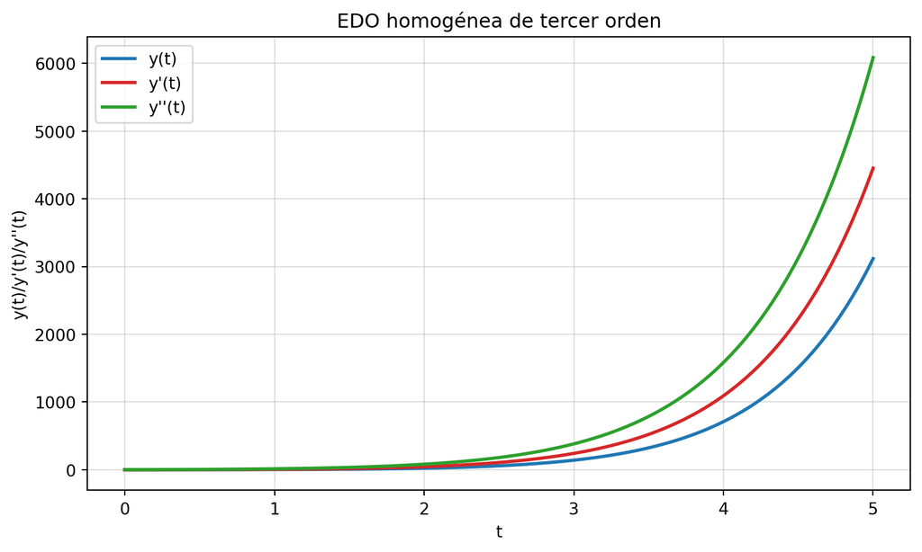

```python
def f14(t, U):
    u1, u2, u3 = U
    return [u2, u3, u1 - 3*u2 + 3*u3]

resolver_y_graficar(f14, 0, 5, [1, 0, 1], ['y(t)', "y'(t)", "y''(t)"],
                    titulo='EDO homogénea de tercer orden');
```

La ecuación característica es $(\lambda-1)^{3}=0$, así que la solución crece como $P(t)\,e^{t}$ con $P$ un polinomio de grado a lo sumo 2.

# Ejercicio 15

**EDO de tercer orden con término no lineal**

$$\begin{equation}
y''' + y^2 = 0,\quad y(0) = 1,\ y'(0) = 0,\ y''(0) = 0
\end{equation}$$

$$u_1'=u_2,\qquad u_2'=u_3,\qquad u_3'=-u_1^{2}.$$

**Código**

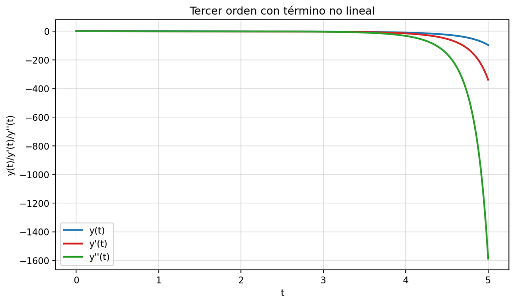

```python
def f15(t, U):
    u1, u2, u3 = U
    return [u2, u3, -u1**2]

resolver_y_graficar(f15, 0, 5, [1, 0, 0], ['y(t)', "y'(t)", "y''(t)"],
                    titulo='Tercer orden con término no lineal');
```

# Ejercicio 16

**Oscilador cúbico forzado**

$$\begin{equation}
y''' + y'' + y^3 = \cos(t),\quad y(0) = 0,\ y'(0) = 1,\ y''(0) = 0
\end{equation}$$

$$u_1'=u_2,\qquad u_2'=u_3,\qquad u_3'=\cos(t)-u_3-u_1^{3}.$$

**Código**

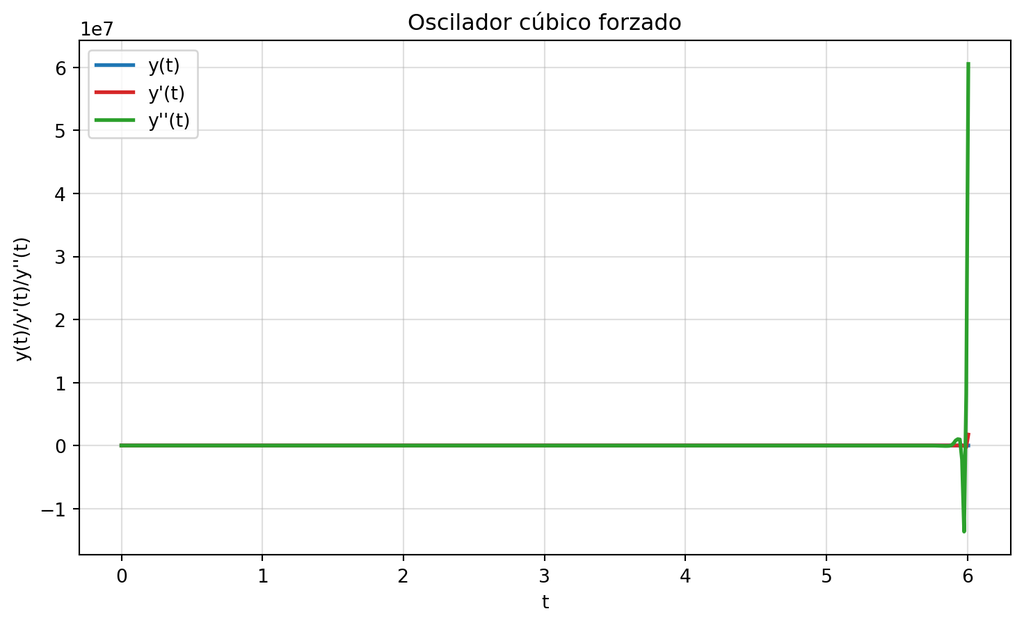

```python
def f16(t, U):
    u1, u2, u3 = U
    return [u2, u3, np.cos(t) - u3 - u1**3]

resolver_y_graficar(f16, 0, 15, [0, 1, 0], ['y(t)', "y'(t)", "y''(t)"],
                    titulo='Oscilador cúbico forzado');
```

# Ejercicio 17

**Ecuación tipo dispersión (Korteweg-de Vries simplificada)**

$$\begin{equation}
y''' - 6yy' = 0,\quad y(0) = 2,\ y'(0) = 0,\ y''(0) = -1
\end{equation}$$

$$u_1'=u_2,\qquad u_2'=u_3,\qquad u_3'=6\,u_1 u_2.$$

**Código**

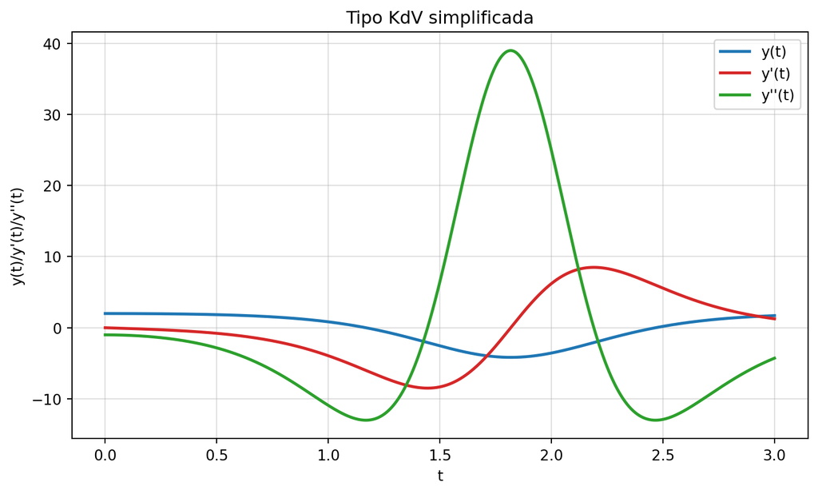

```python
def f17(t, U):
    u1, u2, u3 = U
    return [u2, u3, 6*u1*u2]

resolver_y_graficar(f17, 0, 3, [2, 0, -1], ['y(t)', "y'(t)", "y''(t)"],
                    titulo='Tipo KdV simplificada');
```

# Ejercicio 18

**Modelo no lineal de conducción**

$$\begin{equation}
y''' = -y y'' + y',\quad y(0) = 1,\ y'(0) = 0,\ y''(0) = -1
\end{equation}$$

$$u_1'=u_2,\qquad u_2'=u_3,\qquad u_3'=-u_1 u_3+u_2.$$

**Código**

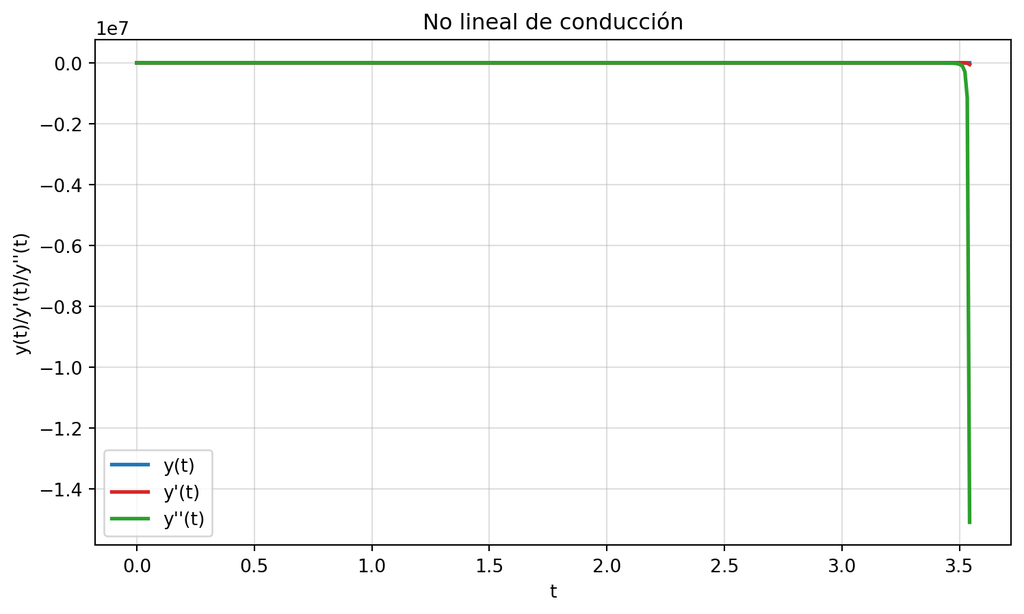

```python
def f18(t, U):
    u1, u2, u3 = U
    return [u2, u3, -u1*u3 + u2]

resolver_y_graficar(f18, 0, 10, [1, 0, -1], ['y(t)', "y'(t)", "y''(t)"],
                    titulo='No lineal de conducción');
```

# Ejercicio 19

Una persona abre una cuenta bancaria con un saldo inicial de $2000$ dólares. Sea $b(t)$ el saldo en la cuenta en el tiempo t. Así, $b(0) = 2000$. El banco paga intereses a una tasa continua del $5\%$ anual. La persona realiza depósitos en la cuenta a una tasa continua de $s(t)$ dólares por año. Supogamos que $s(0) = 500$ y que $s(t)$ está aumentando a una tasa continua del $4\%$ anual (la persona puede ahorrar más conforme aumenta su ingreso con el tiempen). Brinda el sistema de ecuaciones diferenciales ordinarias y gráfica la solución $b(t)$ y $s(t)$.

El saldo crece por dos vías: los intereses ($5\%$ anual sobre $b$) y los depósitos $s(t)$. La tasa de depósito a su vez crece al $4\%$ anual. El sistema es
$$\frac{db}{dt}=0.05\,b+s,\qquad \frac{ds}{dt}=0.04\,s,$$
con $b(0)=2000$ y $s(0)=500$.

**Código**

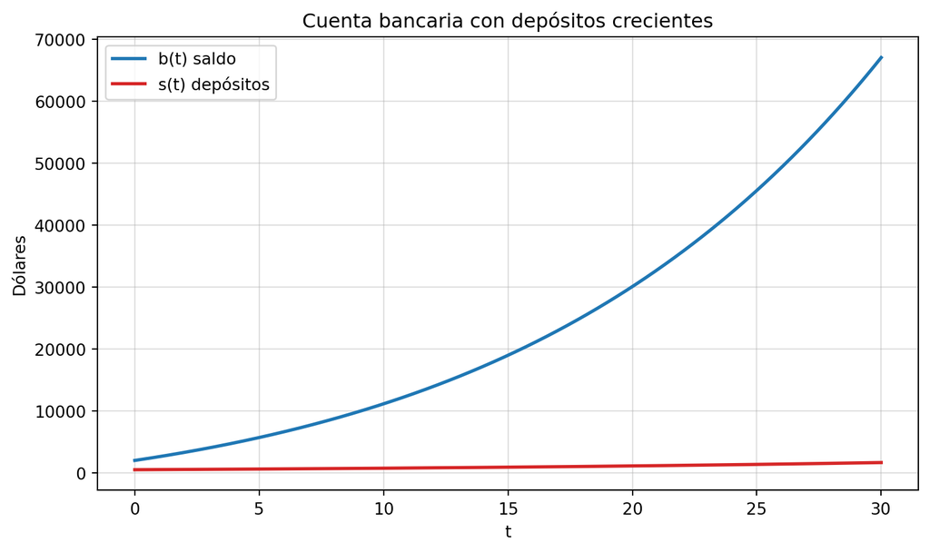

```python
def f19(t, U):
    b, s = U
    return [0.05*b + s, 0.04*s]

resolver_y_graficar(f19, 0, 30, [2000, 500], ['b(t) saldo', 's(t) depósitos'],
                    titulo='Cuenta bancaria con depósitos crecientes',
                    ylabel='Dólares');
```

Tras 30 años el saldo crece exponencialmente porque los intereses se reinvierten y los depósitos también aumentan; el saldo final supera con claridad lo que se habría obtenido sin depósitos.

# Ejercicio 20

Aproxima la solución del siguiente sistema de ecuaciones diferenciales ordinarias

$$\begin{eqnarray}
x'(t) & = -6 x - 3 y\\
y'(t) & = -15 x + 6y
\end{eqnarray}$$

donde $x(0)= 3$ y $y(0)=2$. Grafica cada una de las funciones y la trayectoria.

La matriz del sistema tiene traza $0$ y determinante $-81$, así que sus valores propios son $\pm 9$: el origen es un **punto silla** y la solución crece exponencialmente en una dirección, por lo que se usa un intervalo corto.

**Código**

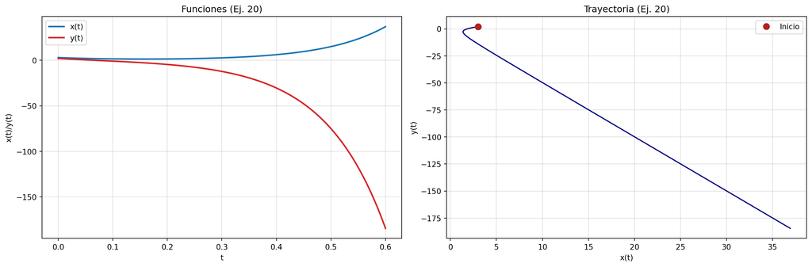

```python
def f20(t, U):
    x, y = U
    return [-6*x - 3*y, -15*x + 6*y]

resolver_funciones_y_trayectoria(f20, 0, 0.6, [3, 2], ['x(t)', 'y(t)'],
                                 titulo='(Ej. 20)');
```

# Ejercicio 21

Considera la interacción de dos especies de animales en un hábitat. Considerando que las poblaciones $x(t)$ y $y(t)$ pueden ser modeladas por medio de las ecuaciones

$$\begin{eqnarray}
x'(t) & = 1.4 x - y\\
y'(t) & = -1.25 x + 3.4y
\end{eqnarray}$$

donde $x(0)=7$ y $y(0)=3$. Grafica cada una de las funciones que brindan la población de cada especie al tiempo $t$.

**Código**

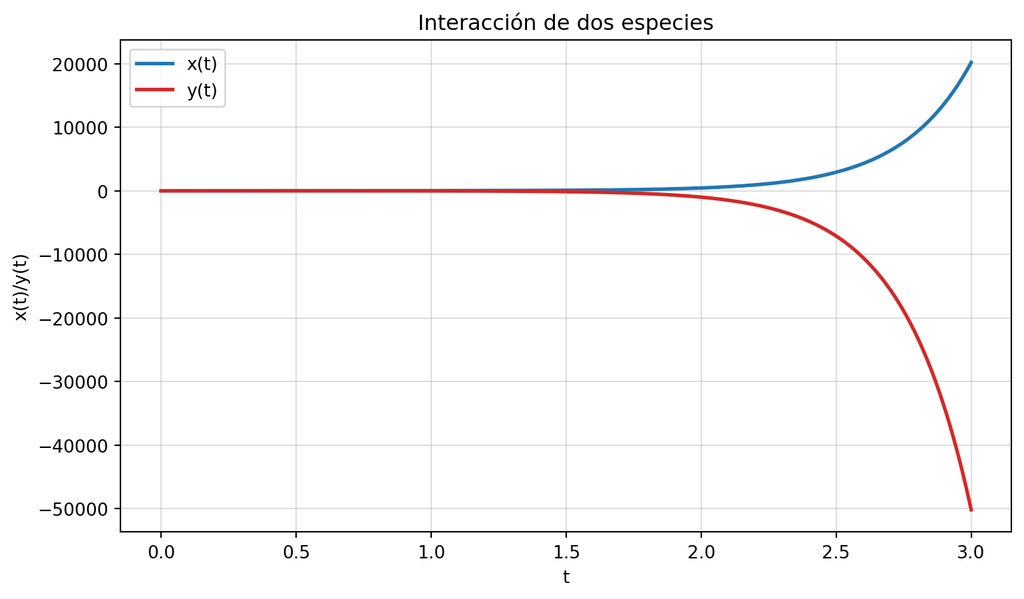

```python
def f21(t, U):
    x, y = U
    return [1.4*x - y, -1.25*x + 3.4*y]

resolver_y_graficar(f21, 0, 3, [7, 3], ['x(t)', 'y(t)'],
                    titulo='Interacción de dos especies');
```

# Ejercicio 22

Aproxima la solución del siguiente sistema de ecuaciones diferenciales ordinarias,

$$\begin{eqnarray}
y'_1(t) & = -6.2 +1.1 y_1 - 0.8 y_2\\
y'_2(t) & = -13.8 +2.1 y_1 -1.2 y_2
\end{eqnarray}$$

con los valores iniciales $y_1(0)=11$, $y_2(0)=4$. Grafica cada una de las funciones y la trayectoria.

Este sistema **no homogéneo** tiene un punto fijo en $(y_1,y_2)=(10,6)$ que es un **foco estable** (valores propios complejos con parte real negativa), por lo que las soluciones espiralan hacia él.

**Código**

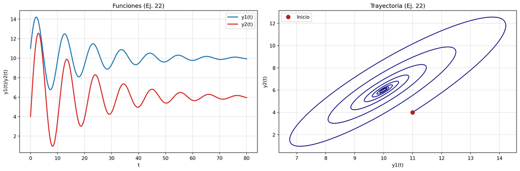

```python
def f22(t, U):
    y1, y2 = U
    return [-6.2 + 1.1*y1 - 0.8*y2, -13.8 + 2.1*y1 - 1.2*y2]

resolver_funciones_y_trayectoria(f22, 0, 80, [11, 4], ['y1(t)', 'y2(t)'],
                                 titulo='(Ej. 22)');
```

Para cada uno de los sistemas de ecuaciones diferenciales ordinarias no lineales con valor inicial grafica las funciones y las respectivas trayectorias.

# Ejercicio 23

**Sistema logístico con depredación**

$$\begin{equation}
\begin{cases}
\frac{dx}{dt} = x(1 - x) - xy \\
\frac{dy}{dt} = -y + xy \\
x(0) = 0.9,\quad y(0) = 0.1
\end{cases}
\end{equation}$$

**Código**

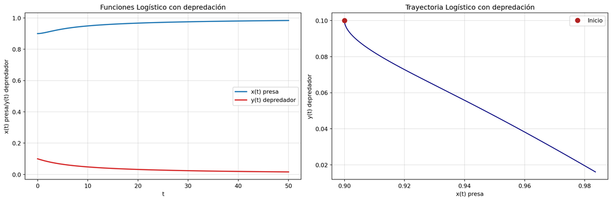

```python
def f23(t, U):
    x, y = U
    return [x*(1-x) - x*y, -y + x*y]

resolver_funciones_y_trayectoria(f23, 0, 50, [0.9, 0.1], ['x(t) presa', 'y(t) depredador'],
                                 titulo='Logístico con depredación');
```

# Ejercicio 24

**Oscilador de Van der Pol**

$$\begin{equation}
\begin{cases}
\frac{dx}{dt} = y \\
\frac{dy}{dt} = \mu (1 - x^2)y - x \\
x(0) = 2,\quad y(0) = 0,\quad \mu = 3
\end{cases}
\end{equation}$$

A continuación se muestra la aproximación de la solución del sistema de ecuaciones diferenciales ordinarias de primer orden y las gráficas de las funciones $x(t)$ y $y(t)$.

**Código**

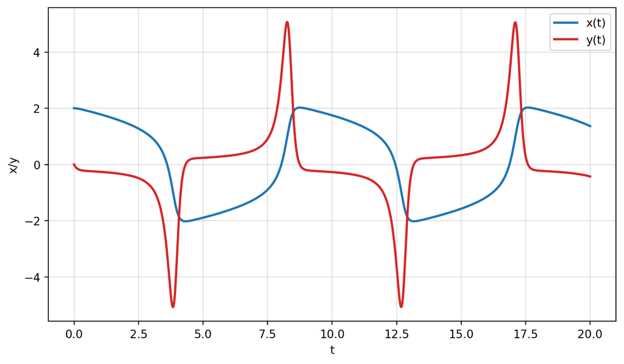

```python
def f(t, X, mu):
  x, y = X
  return[y, mu*(1-x**2)*y-x]


mu = 3
t0 = 0
tf = 20
s0 = [2, 0]
t_values = np.linspace(t0, tf, 5000)

edo_sol = integrate.solve_ivp(f, [t0, tf], s0, t_eval = t_values, args = (mu,))

plt.figure(figsize=(9, 5))
plt.plot(edo_sol.t, edo_sol.y[0], color='tab:blue', lw=2, label = 'x(t)')
plt.plot(edo_sol.t, edo_sol.y[1], color='tab:red',  lw=2, label = 'y(t)')
plt.xlabel('t')
plt.ylabel('x/y')
plt.legend()
plt.grid(True, alpha=0.4)
plt.show()
```

En este caso es posible observar que el sistema de ecuaciones diferenciales ordinarias de primer orden tiene un comportamiento oscilatorio, es decir, las funciones $x(t)$ y $y(t)$ oscilan con el tiempo. Este tipo de comportamiento es característico del oscilador de Van der Pol, donde la no linealidad introducida por el término $\mu (1 - x^2)y$ genera una dinámica compleja que puede incluir oscilaciones limitadas o incluso caos dependiendo del valor de $\mu$. Para observar cómo varía el comportamiento del sistema con diferentes valores de $\mu$, se pueden graficar las trayectorias para varios valores de $\mu$ y comparar los resultados. Estas trayectorias se denominan órbitas del oscilador, y pueden mostrar cómo el sistema evoluciona en el espacio de fases para diferentes condiciones iniciales y parámetros. A continuación se muestra la gráfica de las órbitas del oscilador de Van der Pol para varios valores de $\mu$.

**Órbitas del oscilador**

**Código**

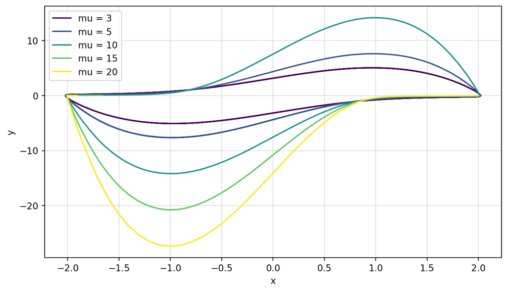

```python
mu_s = [3, 5, 10, 15, 20]

plt.figure(figsize=(9, 5))
cmap = plt.get_cmap('viridis')
for k, mu in enumerate(mu_s):
  edo_sol = integrate.solve_ivp(f, [t0, tf], s0, t_eval = t_values, args = (mu,))
  plt.plot(edo_sol.y[0], edo_sol.y[1],
           color=cmap(k/(len(mu_s)-1)), lw=1.5,
           label = 'mu = ' + str(mu))
plt.xlabel('x')
plt.ylabel('y')
plt.legend()
plt.grid(True, alpha=0.4)
plt.show()
```

# Ejercicio 25

**Sistema de Lotka-Volterra**

$$\begin{equation}
\begin{cases}
\frac{dx}{dt} = \alpha x - \beta xy \\
\frac{dy}{dt} = \delta xy - \gamma y \\
x(0) = 10,\quad y(0) = 5,\quad \alpha = 1.5,\ \beta = 1,\ \delta = 1,\ \gamma = 3
\end{cases}
\end{equation}$$

**Código**

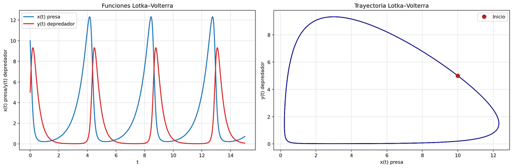

```python
def f25(t, U, a, b, d, g):
    x, y = U
    return [a*x - b*x*y, d*x*y - g*y]

resolver_funciones_y_trayectoria(f25, 0, 15, [10, 5], ['x(t) presa', 'y(t) depredador'],
                                 titulo='Lotka–Volterra',
                                 args=(1.5, 1.0, 1.0, 3.0));
```

El modelo Lotka–Volterra exhibe **oscilaciones cerradas** en el espacio de fases: las poblaciones de presa y depredador oscilan de forma periódica desfasada, sin amortiguarse (el sistema es conservativo).

# Ejercicio 26

**Interacción no lineal seno-coseno**

$$\begin{equation}
\begin{cases}
\frac{dx}{dt} = \sin(y) - x^3 \\
\frac{dy}{dt} = \cos(x) - y^2 \\
x(0) = 1,\quad y(0) = 0
\end{cases}
\end{equation}$$

**Código**

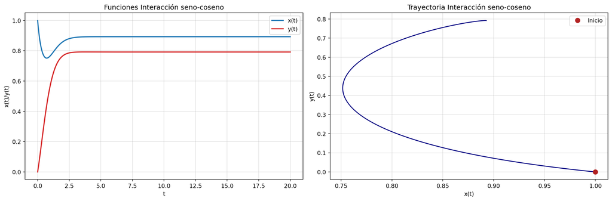

```python
def f26(t, U):
    x, y = U
    return [np.sin(y) - x**3, np.cos(x) - y**2]

resolver_funciones_y_trayectoria(f26, 0, 20, [1, 0], ['x(t)', 'y(t)'],
                                 titulo='Interacción seno-coseno');
```

# Ejercicio 27

**FitzHugh-Nagumo (modelo de neurona)**

$$\begin{equation}
\begin{cases}
\frac{dv}{dt} = v - \frac{v^3}{3} - w + I \\
\frac{dw}{dt} = 0.08(v + 0.7 - 0.8w) \\
v(0) = -1,\quad w(0) = 1,\quad I = 0.5
\end{cases}
\end{equation}$$

**Código**

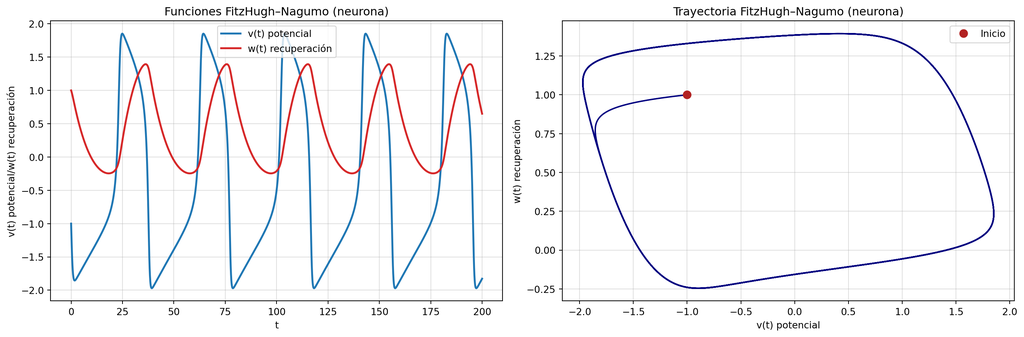

```python
def f27(t, U, I):
    v, w = U
    return [v - v**3/3 - w + I, 0.08*(v + 0.7 - 0.8*w)]

resolver_funciones_y_trayectoria(f27, 0, 200, [-1, 1], ['v(t) potencial', 'w(t) recuperación'],
                                 titulo='FitzHugh–Nagumo (neurona)',
                                 args=(0.5,), n_pts=4000);
```

El modelo reproduce el **disparo periódico de potenciales de acción** de una neurona: $v$ se eleva bruscamente y vuelve a un valor de reposo, mientras $w$ es la variable lenta de recuperación. En el espacio de fases la trayectoria converge a un ciclo límite.

# Ejercicio 28

**Sistema no autónomo**

$$\begin{equation}
\begin{cases}
\frac{dx}{dt} = x \sin(t) + y^2 \\
\frac{dy}{dt} = -y \cos(t) + x \\
x(0) = 1,\quad y(0) = -1
\end{cases}
\end{equation}$$

**Código**

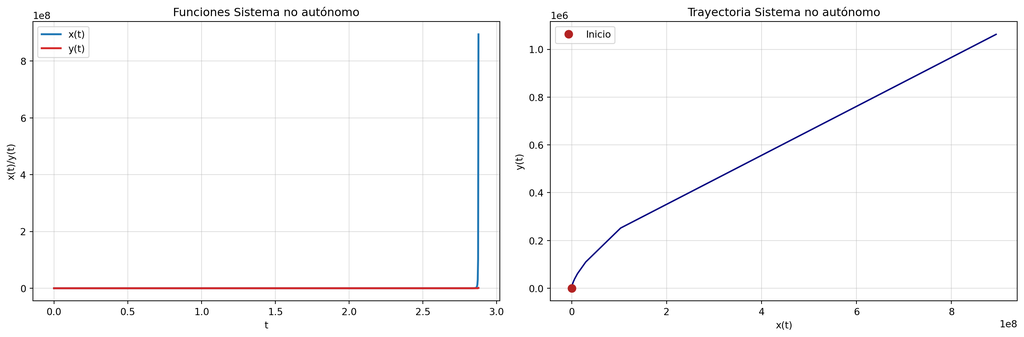

```python
def f28(t, U):
    x, y = U
    return [x*np.sin(t) + y**2, -y*np.cos(t) + x]

resolver_funciones_y_trayectoria(f28, 0, 5, [1, -1], ['x(t)', 'y(t)'],
                                 titulo='Sistema no autónomo');
```

# Ejercicio 29

**Modelo epidemiológico SIR (en este caso no graficar la trayectoria)**

$$\begin{equation}
\begin{cases}
\frac{dS}{dt} = -\beta S I \\
\frac{dI}{dt} = \beta S I - \gamma I \\
\frac{dR}{dt} = \gamma I \\
S(0) = 0.99,\quad I(0) = 0.01,\quad R(0) = 0,\quad \beta = 0.5,\ \gamma = 0.1
\end{cases}
\end{equation}$$

**Código**

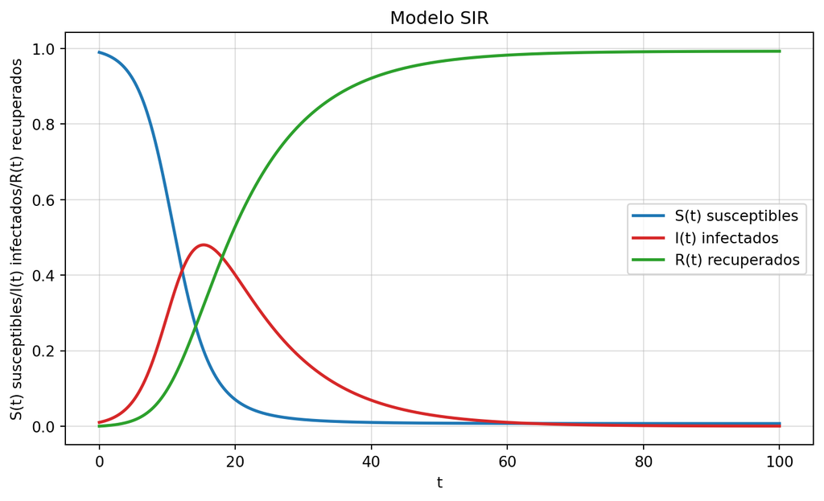

```python
def f29(t, U, beta, gamma):
    S, I, R = U
    return [-beta*S*I, beta*S*I - gamma*I, gamma*I]

resolver_y_graficar(f29, 0, 100, [0.99, 0.01, 0],
                    ['S(t) susceptibles', 'I(t) infectados', 'R(t) recuperados'],
                    titulo='Modelo SIR',
                    args=(0.5, 0.1), n_pts=2000);
```

La curva de infectados $I(t)$ alcanza un máximo (pico de la epidemia) y luego decae, mientras los susceptibles disminuyen monótonamente y los recuperados aumentan. El número básico de reproducción es $R_0=\beta/\gamma=5$, lo que explica que casi toda la población acabe infectándose.